# Genotype diagnostics in DO mice

QTL analysis results are dependent upon the fidelity of the data, and so an important preliminary activity is the careful investigation of the quality of both the genotypes and phenotypes. Diagnosing genotype data problems can be particularly tricky in multi-parent populations, such as Diversity Outbred (DO) mouse populations. In this document, we illustrate our basic strategies for genotype diagnostics in DO mice.

We’ll consider data from [Gatti et al. (2014) G3 4:1623-1633](http://www.g3journal.org/content/4/9/1623.full.pdf), available at [GitHub](https://github.com/rqtl/qtl2data/tree/master/DO_Gatti2014), as well as at the [Mouse Phenome Database](http://phenome.jax.org/db/q?rtn=projects/projdet&reqprojid=289). We first load the data, directly from the web.

```r
library(qtl2geno)
file <- "https://raw.githubusercontent.com/rqtl/qtl2data/master/DO_Gatti2014/do.zip"
do <- read_cross2(file)
```

The data concern 742 DO mice genotyped on the MUGA array, with genotypes at 6376 informative markers. The mice are from generations 3-5 of the DO, and so this lower-resolution genotyping array is likely sufficient. Later generations have been genotyped with the MegaMUGA or GigaMUGA, which have an order of magnitude more markers.

### Sexes

The first thing we check is the sexes of the mice. One can look at the proportion of homozygous genotype calls on the X chromosome, but we find it most informative to look at the SNP array intensities for SNPs on the X and Y chromosomes.

The detailed SNP array data for these mice are available at the [Mouse Phenome Database](http://phenome.jax.org/db/q?rtn=projects/projdet&reqprojid=289), but the file is nearly 500 MB. We’ve extracted the overall intensities for SNPs on the X and Y chromosomes and placed them in CSV files at [GitHub](https://github.com/rqtl/qtl2data/tree/master/DO_Gatti2014/XYint). We’ll work with these extracted data files.

```r
url <- "https://raw.githubusercontent.com/rqtl/qtl2data/master/DO_Gatti2014/XYint/"
xint <- read.csv(paste0(url, "Gatti2014_Xint.csv"))
yint <- read.csv(paste0(url, "Gatti2014_Yint.csv"))
rownames(xint) <- xint[,1]
rownames(yint) <- yint[,1]
xint <- xint[,-1]
yint <- yint[,-1]
```

Let’s grab the sexes of the mice from the cross object, `do`.

```r
sex <- do$covar$Sex
names(sex) <- rownames(do$covar)
```

There’s a bit of a problem, that the individual IDs in `xint` and `yint` are like `JAXW202-3168`, while those in the `do` object are like `JAXW202.3168`. So we’ll replace the hyphens with periods, in the former.

```r
rownames(xint) <- sub("-", ".", rownames(xint), fixed=TRUE)
rownames(yint) <- sub("-", ".", rownames(yint), fixed=TRUE)
```

Let’s also reorder the `sex` vector so the names are aligned, and double-check that they are all aligned.

```r
sex <- sex[rownames(xint)]
all(names(sex) == rownames(xint) & names(sex) == rownames(yint))
```

```
## [1] TRUE
```

It turns out that many of the SNPs don’t do a great job of differentiating between males and females. So let’s first do a t-test for sex differences in intensities at each SNP, and use only the SNPs that show a small P-value.

```r
xp <- apply(xint, 2, function(a) -log10(t.test(a ~ sex)$p.value))
yp <- apply(yint, 2, function(a) -log10(t.test(a ~ sex)$p.value))
```

Of the 495 SNPs on the X chromosome, 412 have -log<sub>10</sub> p-value > 3, and of the 5 SNPs on the Y chromosome, 3 have -log<sub>10</sub> p-value > 3.

Let’s calculate the average intensities across those SNPs.

```r
ave_xint <- rowMeans(xint[,xp > 3])
ave_yint <- rowMeans(yint[,yp > 3])
```

Let’s make a scatterplot of these, colored by sex. I’ll use `iplot()` from [R/qtlcharts](http://kbroman.org/qtlcharts), so that the plot is interactive, in that when hovering over a point, you’ll get a tool tip with the individual ID.

As we’ll see, there are 4 female mice with rather low X chromosome intensities. I’m going to plot the points in a way that the females will appear on top.

```r
library(qtlcharts)
o <- rev(order(sex))
iplot(ave_xint[o], ave_yint[o], indID=names(ave_xint)[o], group=sex[o],
      chartOpts=list(pointcolor=c("Orchid", "slateblue"),
                     xlab="X chr intensity",
                     ylab="Y chr intensity"))
```

[interactive chart not shown]

The females are below and to the right (high X intensity, low Y intensity), while the males are above and to the left (low X intensity, high Y intensity). But there is one female (JAXW202.2675) who sits in the middle of the cloud of males, and there are three females (JAXW202.2726, JAXW202.3162, JAXW202.3175) that are in the bottom-left of the figure (low intensities for both the X and the Y). The males all look okay: there are 0 males with average X intensity > 0.9.

I’m inclined to think that JAXW202.2675 is really male; the other three unusual females could be XO, or they could be poorly behaved DNA samples.

Let’s also look at the frequency of heterozygote genotypes on the X chromosome. We’ll make a scatterplot of the proportion of heterozygote calls on the X chromosome versus the overall proportion of missing genotypes.

```r
phetX <- rowSums(do$geno$X == 2)/rowSums(do$geno$X != 0)
pmis <- n_missing(do, summary="proportion")
iplot(pmis, phetX, indID=ind_ids_geno(do), group=do$covar$Sex,
      chartOpts=list(pointcolor=c("Orchid", "slateblue"),
                     xlab="Proportion missing genotypes",
                     ylab="Proportion het on X chr"))
```

[interactive chart not shown]

Among males with <5% missing genotypes, here are the five with the highest proportion of heterozygous calls on the X chromosome:

```r
sort(phetX[do$covar$Sex=="M" & pmis < 0.05], decreasing=TRUE)[1:5]
```

```
## JAXW202.2663 JAXW202.3013 JAXW202.3251 JAXW202.3294 JAXW202.3034
##   0.03529412   0.02571429   0.02366864   0.02017291   0.01971831
```

Among females with <5% missing genotypes, here are the six with the lowest proportion of heterozygous calls on the X chromosome:

```r
sort(phetX[do$covar$Sex=="F" & pmis < 0.05])[1:6]
```

```
## JAXW202.2726 JAXW202.3162 JAXW202.2675 JAXW202.2490 JAXW202.3175 JAXW202.2149
##  0.005555556  0.008498584  0.011111111  0.019178082  0.040229885  0.052341598
```

The lowest five include the four problem samples identified above, based on array intensities, plus also `JAXW202.2490`, with heterozygous frequency of 2%, but this might just be real.

### Sample duplicates

We next look for pairs of samples with unusually similar genotype data, which may be sample duplicates or sample contamination. We use the function `compare_geno()` in [R/qtl2geno](https://github.com/rqtl/qtl2geno), which uses the raw SNP data and simply calculates the proportion of matching SNP genotypes for each pair of mice.

```r
cg <- compare_geno(do)
```

The `summary()` function will show the pairs with proportions > 0.9.

```r
summary(cg)
```

```
##          ind1         ind2 prop_match n_mismatch n_typed n_match index1 index2
##  JAXW202.2341 JAXW202.2426       1.00          4    4326    4322    185    255
##  JAXW202.2340 JAXW202.2341       0.98         66    4013    3947    184    185
##  JAXW202.2570 JAXW202.2608       0.97         96    3653    3557    335    366
##  JAXW202.2340 JAXW202.2426       0.96        150    3787    3637    184    255
##  JAXW202.2608 JAXW202.2624       0.96        156    3768    3612    366    369
##  JAXW202.2624 JAXW202.2634       0.95        172    3595    3423    369    373
```

There is one pair that has matching genotypes at all but 4 of the 4326 markers at which they were both typed. And actually it’s a trio (JAXW202.2426, JAXW202.2340, JAXW202.2341) with very similar genotypes. And there seems to be another set of four mice with very similar genotypes.

Let’s look at a histogram of the proportions of matching genotypes across all pairs. The tick marks below help to show what’s going on in the tail of the distribution, and I’ve highlighted pairs in red that have ~80% matching genotypes, and in blue pairs that match at >90% of SNPs.

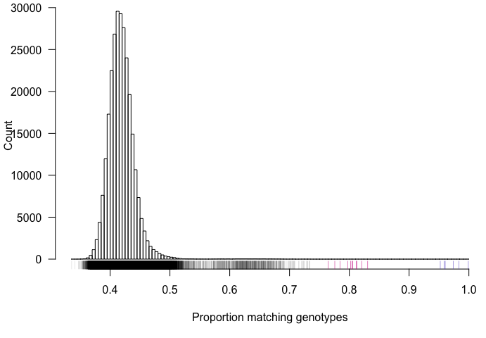

```r
p <- cg[upper.tri(cg)]
par(mar=c(5.1,4.1,0.1,0.1))
hist(p, breaks=201, main="", ylab="Count", las=1,
     xlab="Proportion matching genotypes")
rug(p[p < 0.75], col="#00000030")
rug(p[p >= 0.75 & p < 0.9], col="violetred")
rug(p[p >= 0.90], col="slateblue")
```

As we’ll see in the next section, these mice all have appreciable missing genotype data, and so the issue may not be sample duplicates but rather poor quality DNAs.

### Sample quality

There are three main checks of sample quality: the proportion of missing data, the inferred number of crossovers, and the estimated number of genotyping errors.

```r
pmis_ind <- sort(n_missing(do, "individual", "proportion"), decreasing=TRUE)
iplot(seq(along=pmis_ind), pmis_ind*100,
      chartOpts=list(xlab="Mice (sorted)", ylab="Percent missing genotypes",
                     ylim=c(0,max(pmis_ind)*101)))
```

[interactive chart not shown]

There are 18 mice with >10% missing genotype data. Another 34 mice are missing between 5 and 10% of genotypes.

Also look at genotype frequencies in the raw SNP data, for individuals with <5% missing genotypes.

```r
g <- do.call("cbind", do$geno[1:19])
p <- t(apply(g, 1, function(a) { tab <- table(factor(a, levels=0:3))[-1]; tab/sum(tab) }))
itriplot(p[pmis<0.05,], chartOpts=list(labels=c("A", "H","B")))
```

[interactive chart not shown]

Let’s look at estimates of the total number of crossovers, across the genome, for each mouse. We first calculate the genotype probabilities, which can take a bit of time.

```r
pr <- calc_genoprob(do, error_prob=0.002, map_function="c-f")
```

We next find the most probable genotype at each location. (I prefer this to Viterbi which seeks the most probable sequence of genotypes along each chromosome, though that is another possibility; see the `viterbi()` function.) We then use `count_xo()` to get the estimated numbers of crossovers.

```r
v <- maxmarg(pr)
n_xo <- count_xo(v)
```

Let’s plot the numbers of crossovers across the genome (obtained by `rowSums()`) against the proportion of missing data.

```r
iplot(pmis_ind[rownames(n_xo)]*100, rowSums(n_xo),
      chartOpts=list(xlab="Percent missing genotypes",
                     ylab="Number of crossovers"))
```

[interactive chart not shown]

The only clear outliers, in terms of numbers of crossovers, are the mice with high rates of missing data; these tend to have low estimated numbers of crossovers, which is perhaps no surprise.

Calculate error lod scores and combine.

```r
errlod <- calc_errorlod(do, pr)
errlod <- do.call("cbind", errlod)
```

Histogram of the error LOD scores. We really only care about values >4 or so.

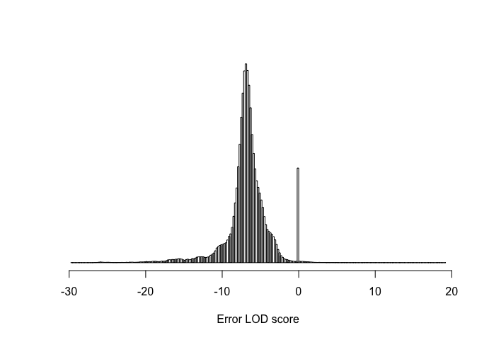

```r
hist(errlod, breaks=200, xlab="Error LOD score", ylab="", yaxt="n", main="")
```

Histogram of numbers of problems by individual. No individual has more than 13 error LOD scores >4.

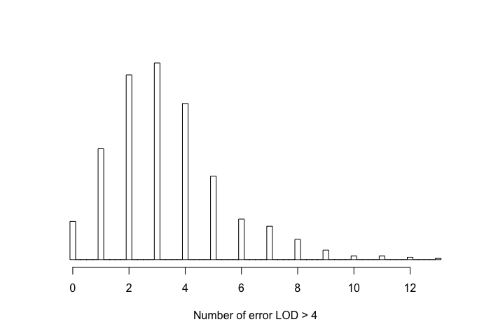

```r
hist(rowSums(errlod>4), breaks=seq(-0.1, 13.1, by=0.2),
     xlab="Number of error LOD > 4", ylab="", yaxt="n", main="")
```

The distribution by marker is quite different. The large error LOD scores are concentrated on a smaller number of markers. Here’s a plot of percent error LOD scores >4, by marker.

```r
chr <- rep(names(do$gmap), sapply(do$gmap, length))
colme <- colMeans(errlod>4)*100

iplot(1:ncol(errlod), colme,
      indID=paste0(colnames(errlod), " (chr ", chr, ")"),
      chartOpts=list(ylab="Percent of error LOD > 4",
                     xlab="Marker index"))
```

[interactive chart not shown]

Of the 6376 markers, there are 5 with >10% problems, and 18 with >5% problems. But 96% of markers have no problems at all.

### Marker quality

Proportion missing.

```r
pmis_mar <- n_missing(do, "marker", "proportion")
```